# R Notebook

Mar 28, 2018

### Updated diversity statistics for Julia

Hey Julia, thanks for being patient as it’s taken me a while to get back to you. This is the most recent version of the D-val table, with some additional figures and analysis that Valerie asked for. Most steps should be annotated - hope this can be followed.

### Parameters to change in notebook

**These parameters control how tests are conducted** div.q : The hill diversity numbers that are used in this analysis (default is 0, 1, 2) n.sim : The number of simulations used in permutational ANOVA tests pool.id : The index positions of identifying columns in the pool dataset (sample and zone columns no longer used) zone.id : The index positions of identifying columns in the zone dataset (sample column no longer used)

```r
# !!! Parameters to change !!! #
# !!! Don't touch anything else !!! #

div.q <- c(0:2) # Hill number diversity values
n.sim <- 9999 # Number of perumtations
pool.id <- c(1:5) # ID columns for by pool datasets (Sample ID and zone are no longer relevant and are removed)
zone.id <- c(1:6) # ID columns for by zone datasets (sample ID is no longer relevant and is removed)
site.id <- c(1:4)
```

### Steps for analysis:

1. Calculate diversity statistics for all hierarchical levels and values of Q:

Lowest hierarchical level

- Alpha (zone) - average community diversity of a “zone” sample (aggregation of 3 samples taken within each zone)
- Beta (zone) - relationship between average pool diversity and average zone diversity
- Alpha (pool) - average community diversity of a “pool” sample (aggregation of 3 zone samples taken within each pool)
- Beta (pool) - relationship between average pool diversity and average site diversity
- Gamma (site) - all species found within a site (aggregation of all pool samples taken)

Highest hierarchical level

2. Visualize these observed values:
3. Run 2 types of permutation tests to determine statistical differences:
- For hierachical levels that contain more than 1 observation per group (not $\beta_{pool}$ or $\gamma_{site}$), I run a permutational ANOVA test. This test calculates the F value for the observed data (ratio of total variance explained to residual error) for the observed set of data, then scrambles the labels some number of times and does the same, ultimately comparing the number of times that this observed value is greater than the randomized value.
- For hierarchical levels that contain 1 observation per group ($\beta_{pool}$ or $\gamma_{site}$), I conducted a standard permutation test. This is similar to the permutational ANOVA, but instead of comparing F-values, it compares the observed value of the sample to a distribution generated by random permutations of the data.

### Step 1: Calculate diversity statistics for all hierarchical levels and values of Q:

This step is relatively simple. Here, I’m using the Jost diversity calculation function to get values of $\alpha_{zone}$, $\alpha_{pool}$, and $\gamma_{site}$. From these calculations, I then calculate beta diversity, which is the ratio between average alpha diversity and average gamma diversity.

These calculations form the fundamental basis for all subsequent tests of significance and cross-site comparisons.

```r
# Defining alpha-diversity calculation function:
calc_alpha <- function(x, q, sample.weight){
  return(d_calc(x, q = q, sample.weight)[[1]][[1]][1])
}

output <- list()
zone_output <- list()

for(qval in unique(div.q)){

  z.alpha = apply(X = normalize_rows(by.zone[,-zone.id]),
      FUN = calc_alpha,
      MARGIN = 1,
      q = qval,
      sample.weight = 1)

  p.alpha = apply(X = normalize_rows(by.pool[,-pool.id]),
        FUN = calc_alpha,
        MARGIN = 1,
        q = qval,
        sample.weight = 1)

  s.gamma = apply(X = normalize_rows(by.site[,-site.id]),
        FUN = calc_alpha,
        MARGIN = 1,
        q = qval,
        sample.weight = 1)

  all_alpha = data.frame(div = c(z.alpha, p.alpha, s.gamma),
                      level = factor(c(rep("zone", length(z.alpha)), rep("pool", length(p.alpha)), rep("site", length(s.gamma))),
                                     levels = c("zone", "pool", "site")),
                      zone_id = c(by.zone$Zone, rep("None", nrow(by.pool) + nrow(by.site))),
                      pool_id = c(by.zone$Site.ID, by.pool$Site.ID, rep("None", nrow(by.site))),
                      graz = c(by.zone$Grazing, by.pool$Grazing, by.site$Grazing),
                      year = c(by.zone$Year, by.pool$Year, by.site$Year))

  all_alpha$stat = rep("alpha", nrow(all_alpha))

  # Calculating beta diversity values (gamma / alpha)

  mean_zone = all_alpha %>% filter(level == "zone") %>% group_by(year, pool_id) %>% summarise(meandiv = mean(div))
  zone_beta = left_join(all_alpha %>% filter(level == "pool") %>% group_by(pool_id, year), mean_zone) %>% mutate(beta = div / meandiv)

  mean_pool = all_alpha %>% filter(level == "pool") %>% group_by(year) %>% summarise(meandiv = mean(div))
  pool_beta = left_join(all_alpha %>% filter(level == "site") %>% group_by(year), mean_pool) %>% mutate(beta = div / meandiv)

  all_beta = data.frame(div = c(zone_beta$beta, pool_beta$beta),
                        stat = rep("beta", nrow(zone_beta) + nrow(pool_beta)),
                        level = factor(c(rep("zone", nrow(zone_beta)), rep("pool", nrow(pool_beta))),
                                       levels = c("zone", "pool", "site")),
                        zone_id = c(rep("None", nrow(by.pool) + nrow(by.site))),
                        pool_id = c(by.pool$Site.ID, rep("None", nrow(by.site))),
                        graz = c(by.pool$Grazing, by.site$Grazing),
                        year = c(by.pool$Year, by.site$Year))

  # Combining into one master datasheet
  div_hierarchy = bind_rows(all_alpha, all_beta)
  div_hierarchy$q = rep(qval, nrow(div_hierarchy))

  output[qval + 1] = list(div_hierarchy)

  # Zone level diversity statistic comparison:
  z.gamma = apply(X = normalize_rows(by.zone_all[,-c(1:5)]),
        FUN = calc_alpha,
        MARGIN = 1,
        q = qval,
        sample.weight = 1)

  colnames(by.zone_all)[1:3] = c("graz", "year", "zone_id")
  by.zone_all$year = as.numeric(by.zone_all$year)

  mean_zone = all_alpha %>% filter(level == "zone") %>% group_by(zone_id, year, graz) %>% summarise(alpha = mean(div))

  alpha_zone = all_alpha %>% filter(level == "zone") %>% group_by(zone_id, year, graz)

  zone_specific = left_join(cbind(by.zone_all[,c(1:5)], "gamma" = z.gamma), mean_zone) %>%
    mutate(beta = gamma / alpha)

  zone_specific = zone_specific %>%
    group_by(graz, year, zone_id) %>%
    gather(key = "level", value = "div",
           alpha, beta, gamma)

  zone_specific$q = rep(qval, nrow(zone_specific))

  zone_output[qval + 1] = list(zone_specific)

  }

head(output[[1]])
```

```
##   div level    zone_id pool_id   graz year  stat q
## 1  12  zone       Pool   B3-91 Grazed    1 alpha 0
## 2  16  zone       Pool   B3-91 Grazed    2 alpha 0
## 3  12  zone       Pool   B3-91 Grazed    3 alpha 0
## 4  15  zone Transition   B3-91 Grazed    1 alpha 0
## 5  18  zone Transition   B3-91 Grazed    2 alpha 0
## 6  16  zone Transition   B3-91 Grazed    3 alpha 0
```

```r
head(zone_output[[1]])
```

```
## # A tibble: 6 x 8
## # Groups:   graz, year, zone_id [6]
##     graz  year    zone_id Quadrat.. com.weight level      div     q
##    <chr> <dbl>      <chr>     <int>      <dbl> <chr>    <dbl> <int>
## 1 Grazed     1       Pool        84  0.3333333 alpha 12.57143     0
## 2 Grazed     1 Transition        84  0.3333333 alpha 15.71429     0
## 3 Grazed     1     Upland        84  0.3333333 alpha 11.07143     0
## 4 Grazed     2       Pool        84  0.3333333 alpha 13.28571     0
## 5 Grazed     2 Transition        84  0.3333333 alpha 18.50000     0
## 6 Grazed     2     Upland        84  0.3333333 alpha 10.78571     0
```

### Step 2: Display this information graphically.

It’s clear that the zones are different from one another, but I don’t know if it’s enough to dampen any changes, as Valerie was curious about. More detail below.

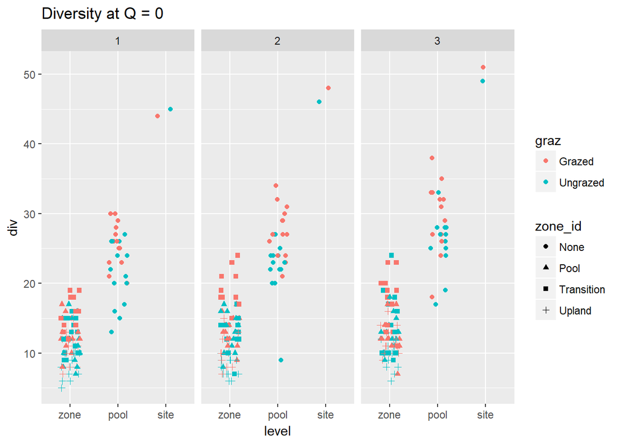

```r
output[[1]] %>% filter(stat == "alpha") %>%
  ggplot(aes(x = level,
             y = div,
             color = graz,
             shape = zone_id))+
  geom_jitter(height = 0, width = .2) +
  facet_wrap(~ year) +
  ggtitle("Diversity at Q = 0")
```

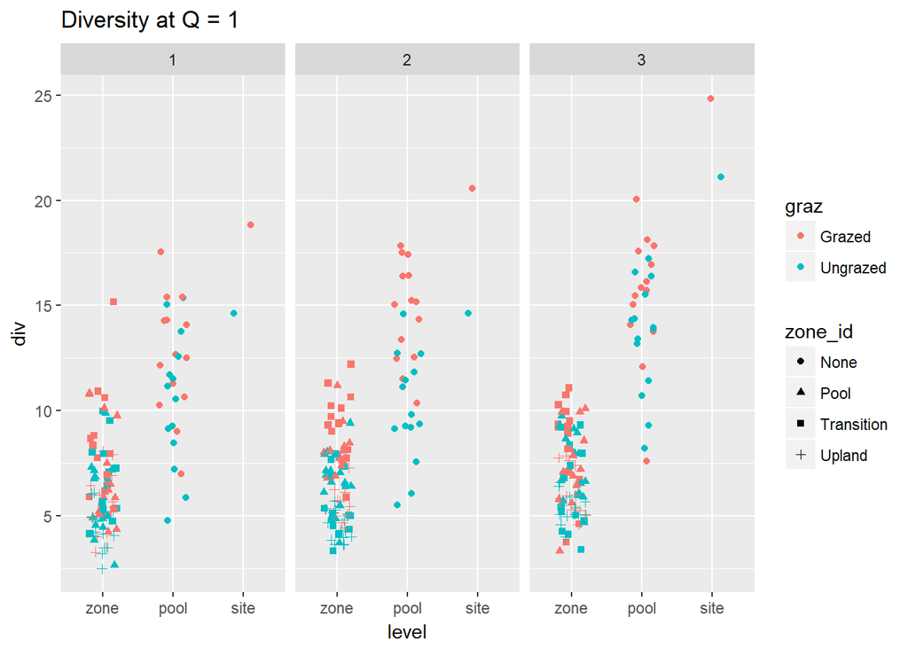

```r
output[[2]] %>% filter(stat == "alpha") %>%
  ggplot(aes(x = level,
             y = div,
             color = graz,
             shape = zone_id))+
  geom_jitter(height = 0, width = .2) +
  facet_wrap(~ year) +
  ggtitle("Diversity at Q = 1")
```

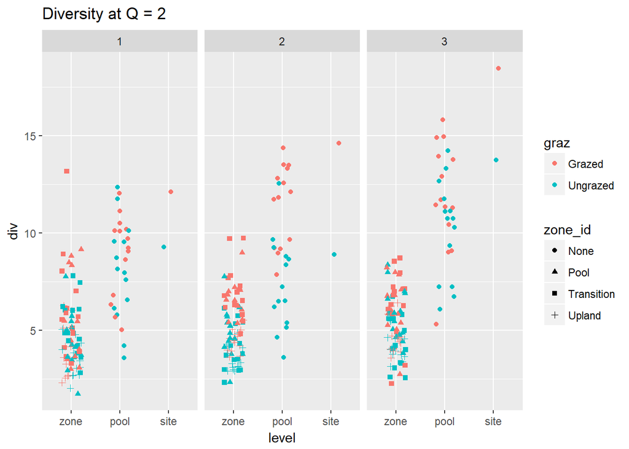

```r
output[[3]] %>% filter(stat == "alpha") %>%
  ggplot(aes(x = level,
             y = div,
             color = graz,
             shape = zone_id))+
  geom_jitter(height = 0, width = .2) +
  facet_wrap(~ year) +
  ggtitle("Diversity at Q = 2")
```

### Diversity of the Individual Zones

To help address Valerie’s questions, I’ve also plotted the alpha and gamma diversity of the zones, if we compare the average diversity of each sample, relative to the total diversity of zone samples in the site. You miss out on the nice hierarchical comparison in this way, as you can’t aggregate to pools without losing influence of the specific zones, but they are different from one another. However, I don’t really know if you see evidence of a “dampened effect”

**Here’s the raw data for the zones:**

```r
spread(select(bind_rows(zone_output), -com.weight), key = graz, value = div)
```

```
## # A tibble: 81 x 7
## # Groups:   year, zone_id [9]
##     year    zone_id Quadrat.. level     q    Grazed  Ungrazed
##    <dbl>      <chr>     <int> <chr> <int>     <dbl>     <dbl>
##  1     1       Pool        84 alpha     0 12.571429 11.571429
##  2     1       Pool        84 alpha     1  7.051432  5.824193
##  3     1       Pool        84 alpha     2  5.409051  4.442518
##  4     1       Pool        84  beta     0  2.545455  3.024691
##  5     1       Pool        84  beta     1  2.337235  2.348167
##  6     1       Pool        84  beta     2  2.300850  1.736430
##  7     1       Pool        84 gamma     0 32.000000 35.000000
##  8     1       Pool        84 gamma     1 16.480850 13.676180
##  9     1       Pool        84 gamma     2 12.445417  7.714121
## 10     1 Transition        84 alpha     0 15.714286 12.285714
## # ... with 71 more rows
```

Plotting these zone diversity values:

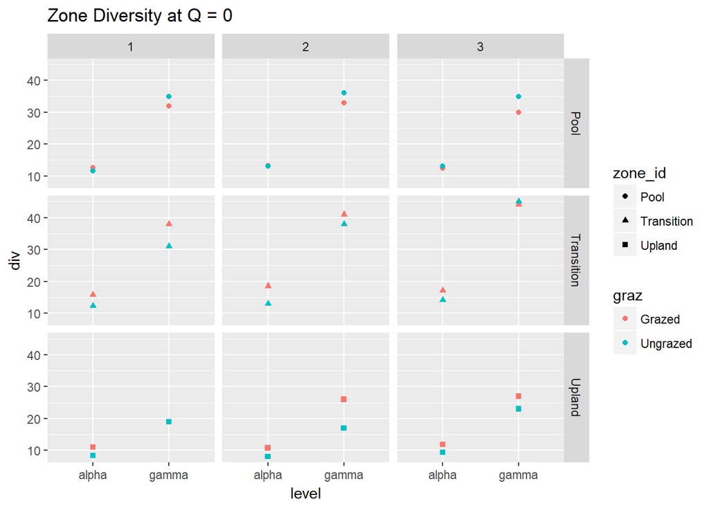

```r
zone_output[[1]] %>%
  filter(level != "beta") %>%
  ggplot(aes(x = level,
             y = div,
             color = graz,
             shape = zone_id))+
  geom_point() +
  facet_grid(zone_id ~ year) +
  ggtitle("Zone Diversity at Q = 0")
```

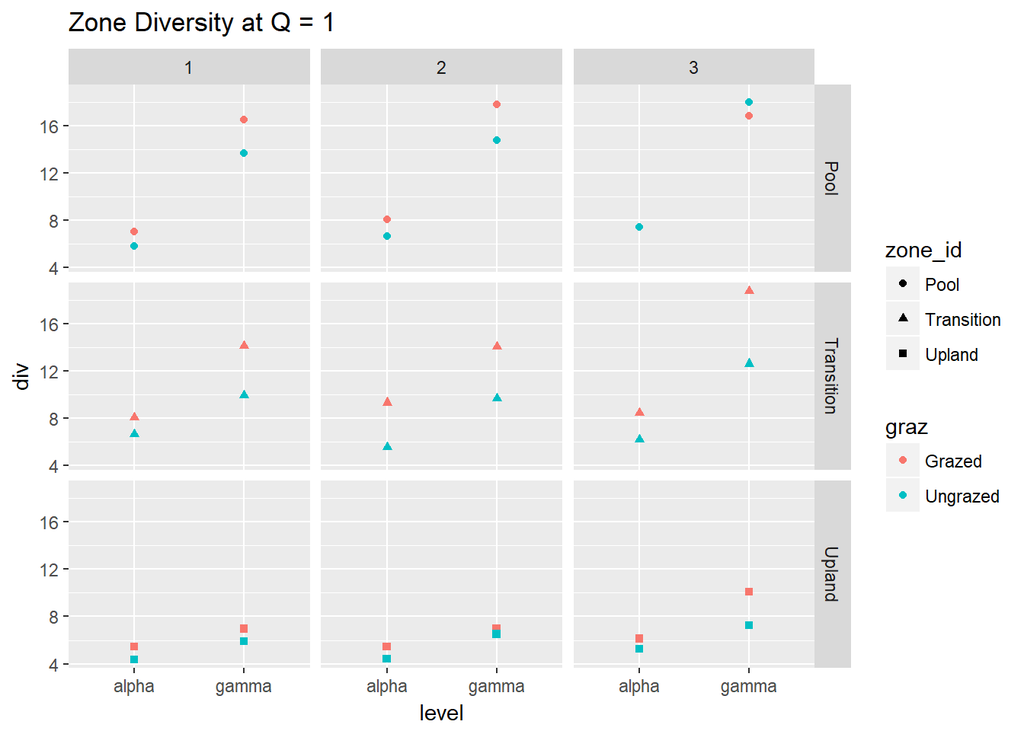

```r
zone_output[[2]] %>%
  filter(level != "beta") %>%
  ggplot(aes(x = level,
             y = div,
             color = graz,
             shape = zone_id))+
  geom_point() +
  facet_grid(zone_id ~ year) +
  ggtitle("Zone Diversity at Q = 1")
```

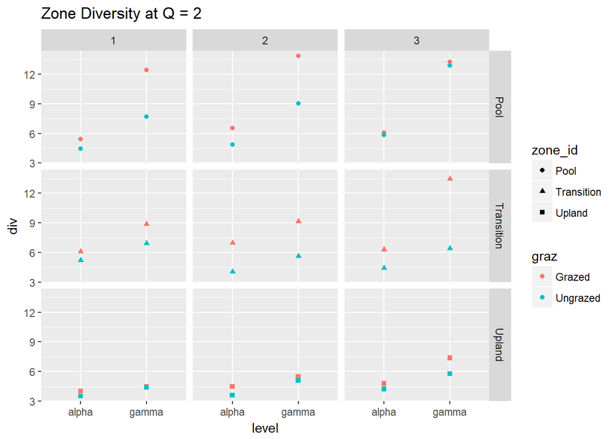

```r
zone_output[[3]] %>%
  filter(level != "beta") %>%
  ggplot(aes(x = level,
             y = div,
             color = graz,
             shape = zone_id))+
  geom_point() +
  facet_grid(zone_id ~ year) +
  ggtitle("Zone Diversity at Q = 2")
```

# Significance Testing:

To conduct significance testing, I will be performing two separate nonparemetric tests (described above):

- Permutation F-test (permutation ANOVA)
- Standard permutation test

The first involves a function in the lmPerm library, while the second is a more complicated custom function that randomizes treatment labels (grazed/ungrazed) within a year, and calculates the difference in diversity. The fraction of observations that have an absolute difference greater than the observed difference are used to calculate P-values.

### Permutation F-Test

```r
# Permutation-based testing:

library(lmPerm)

permFTest = function(df){

  # Conducts permutation F-test
  mod_output = aovp(div ~ graz, data = df, maxIter = n.sim)

  # Finds p-value
  p_val = c(summary(mod_output)[[1]]$"Pr(Prob)"[1])

  # Returns p_value
  return(data.frame(p_val))

}

# Binds all dataframes together
permF_output = bind_rows(output) %>%

  # Filters to exclude all site-level comparisons
  filter(level != "Site") %>%

  # Groups by relevant columns (level, year, statistic, and q-value)
  group_by(level, year, stat, q) %>%

  # Returns a dataframe of p-values
  do(permFTest(.))
```

[output not shown]

[output cut: 30 more lines]

```r
head(permF_output)
```

```
## # A tibble: 6 x 5
## # Groups:   level, year, stat, q [6]
##    level  year  stat     q      p_val
##   <fctr> <int> <chr> <int>      <dbl>
## 1   zone     1 alpha     0 0.00040004
## 2   zone     1 alpha     1 0.01053640
## 3   zone     1 alpha     2 0.04193971
## 4   zone     1  beta     0 0.90196078
## 5   zone     1  beta     1 0.98039216
## 6   zone     1  beta     2 0.68627451
```

### Permutation Test (Warning - takes a long time to run!)

```r
div.permtest <- function(
  comdat, # Community data
  idcols, # ID columns of community data
  testcol, # Groups to test between
  qval, # Q-value
  n.perm, # Number of permutations (>1000 recommended)
  tails = "two", # Number of tails (can be one or two, two is default)
  direction = NA # Direction of the test, if one tailed
  ){

  # Sets label factor vector
  lab <- as.factor(comdat[,idcols][,colnames(comdat[,idcols]) == testcol])

  # Calculates alpha, beta, and gamma diversity values for each group
  grp.1.val <- unlist(jost_d(comdat[lab == levels(lab)[1],-idcols],
                             q = qval, boot = FALSE)@summary[[1]])[1:3]
  grp.2.val <- unlist(jost_d(comdat[lab == levels(lab)[2],-idcols],
                             q = qval, boot = FALSE)@summary[[1]])[1:3]

  # Establishes difference in values
  obs.diff <- grp.1.val - grp.2.val

  # Creating storage list for permutation test output
  perm.output <- list()

  for( perm in 1:n.perm){

    # Reshuffle label column at random
    permlab <- base::sample(lab, length(lab), replace = F)

    # Recalculates value based on permutation
    perm.1.val <- unlist(jost_d(comdat[permlab == levels(permlab)[1],-idcols],
                                q = qval, boot = FALSE)@summary[[1]])[1:3]
    perm.2.val <- unlist(jost_d(comdat[permlab == levels(permlab)[2],-idcols],
                                q = qval, boot = FALSE)@summary[[1]])[1:3]
    perm.diff <- perm.1.val - perm.2.val

    # Stores difference in value
    perm.output[[perm]] <- perm.diff[1:3]

  }

  # Unlists perm.output and creates dataframe
  sim.vals <- matrix(unlist(perm.output), ncol = 3, byrow = T)
  colnames(sim.vals) <- c("alpha", "beta", "gamma")

  # Significance testing
  div.signif <- c()

  for(divlevel in 1:3){
    if(tails == "two"){
      div.signif[divlevel] <-  (sum(abs(sim.vals[,divlevel]) >= abs(obs.diff[divlevel])) + 1) / (n.perm + 1)
    }else if(tails == "one"){
      if(direction == "postiive"){
        div.signif[divlevel] <-  sum(sim.vals[,divlevel] >= obs.diff[divlevel]) / n.perm
      }else if(direction == "negative"){
        div.signif[divlevel] <- sum(sim.vals[,divlevel] <= obs.diff[divlevel]) / n.perm
      }else{
        stop("'direction' must be 'positive' or 'negative")
      }
    }else{
      stop("'tails' value must be 'one' or 'two'")
    }
  }

  # Assembling output dataframe
  fnctn.output <- list(obs.diff = list(obs.diff[1:3],
                                       div.signif),
                       obs.vals = list(grp.1.val,
                                       grp.2.val),
                       sim.vals = sim.vals)
  names(fnctn.output$obs.diff) = c("vals", "signif")
  names(fnctn.output$obs.vals) = c(levels(lab)[1], levels(lab)[2])

  return(fnctn.output)

}

pool.sig <- list()
counter <- 1
idcols <- pool.id

for(qval in unique(div.q)){

  for(years in unique(by.pool$Year)){

    # Significance testing
    tempdf <- by.pool %>% filter(Year == years)

    permtest.output <- div.permtest(comdat = data.frame(tempdf),
                                    idcols,
                                    testcol = "Grazing",
                                    qval = qval,
                                    n.perm = n.sim)

    pool.sig[counter] <- list(data.frame(stat = c("alpha", "beta", "gamma"),
                                    q = rep(qval, 3),
                                    level = rep("pool", 3),
                                    year = rep(as.numeric(years) - 2014, 3),
                                    p_val = permtest.output$obs.diff$signif))

    counter = counter + 1

  }
}
```

# Merging all diversity values and statistics into a single dataframe

Hopefully this is a little more simple + readable - may be a way to consider formatting your table for the paper?

```r
# Binds significance tables together and standardizes naming convention
sig_all = bind_rows(permF_output,
                    bind_rows(pool.sig) %>% filter(stat != "alpha")) %>%
  ungroup() %>%
  mutate(level = replace(level, level == "pool" & stat == "gamma", "site"))
# Binds everything together in a more readable format
full_table = bind_rows(output) %>%
  mutate(stat = replace(stat, stat == "alpha" & level == "site", "gamma")) %>%
  group_by(level, year, stat, q, graz) %>%
  summarise(div = mean(div)) %>%
  spread(key = graz, value = div) %>%
  left_join(sig_all)
write.csv(x = full_table, "full_div_output.csv")
```